# Loan Data from Prosper : Communicate findings

## by Iyanujesu Akinyefa

## Investigation Overview

> In this investigation, I wanted to look at the characteristics of loans that could be used to predict their borrower APR. The main focus was on the original loan amount, borrower's Prosper rating, loan term, borrower's stated monthly income, Employment Status , Term.

## Dataset Overview

> This data set contains 113,937 loans with 81 variables on each loan, including loan amount, borrower rate (or interest rate), current loan status, borrower income, and many others

## Distribution of Borrower Annual Percentage Rate

The distribution of APR looks multimodal. A small peak centered at 0.1, a large peak centered at 0.2. There is also a small peak centered 0.3. Additionally, there is a very shape peak between 0.35 and 0.36. Only very few loans have APR greater than 0.43.

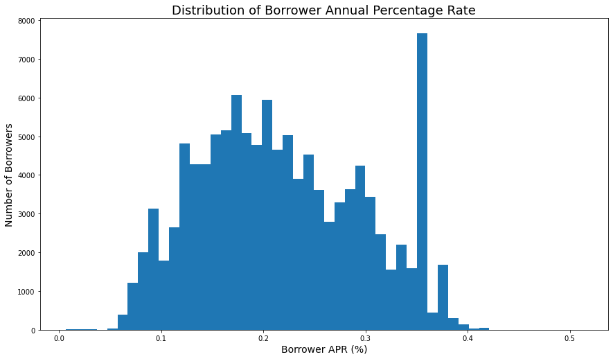

## Distribution of Loan Amount collected by Prosper Borrowers

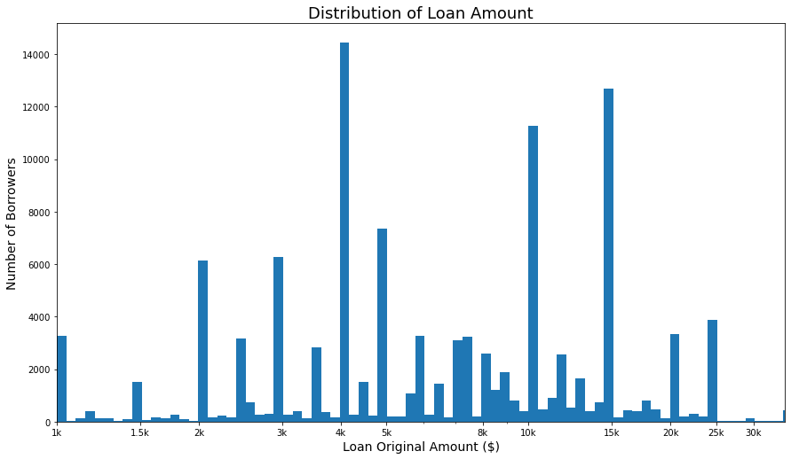

## BorrowerAPR and BorrowerRate

The correlation between BorrowerAPR and BorrowerRate is 0.99, which indicates that they are strongly positive correlatively. Higher BorrowerAPR rate is strongly related to higher BorrowerRate rate

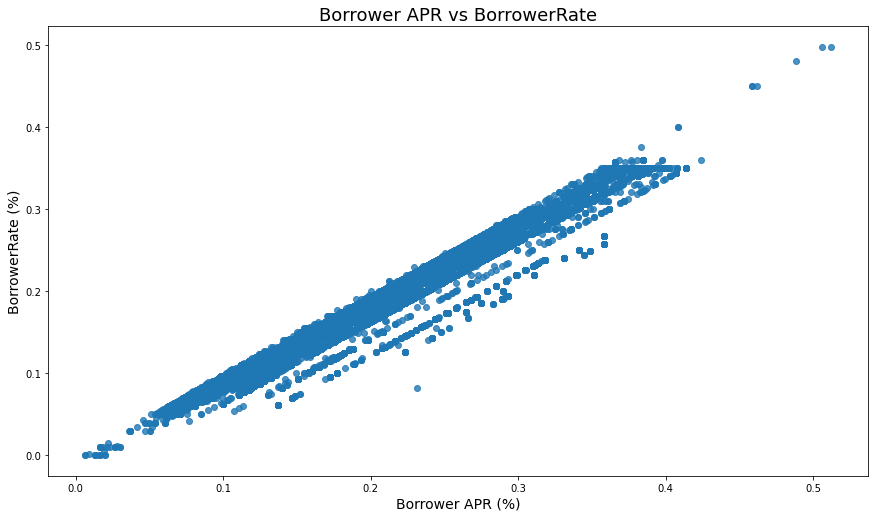

## OriginalLoanAmount and MonthlyLoanPayment

This shows that there is a positive correlation between the original loan amount and the monthly payment of loan. The higher the loan amount, the higher the monthly payment of loan.

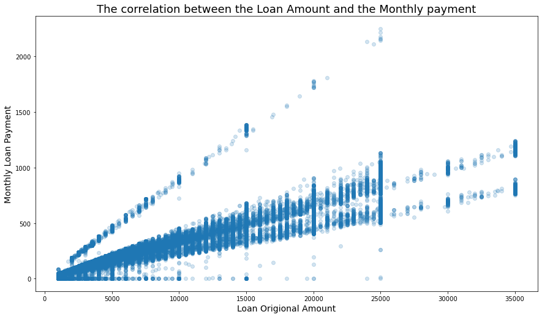

## Prosper Loan Ratings by Term of Loan

There is a interaction between prosper rating and term. Proportionally, there are more 60 month loans on B and C ratings. There is only 36 months loans for HR rating borrowers

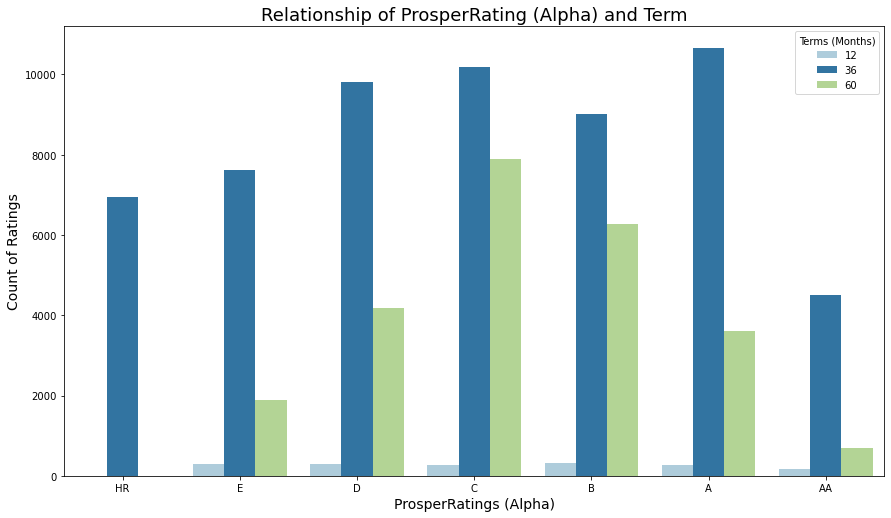